# Logistic Regression - NHIS

Tomas

August 28, 2016

## Regression with Binary Outcomes

### Logistic Regression

The text below is adapted from documents provided from Harvard University’s statistical software workshop along with added problems from Springboard.

This far we have used the `lm` function to fit our regression models. `lm` is great, but limited-in particular it only fits models for continuous dependent variables. For categorical dependent variables we can use the `glm()’ function.

For these models we will use a different dataset, drawn from the National Health Interview Survey. From the CDC website:

> The National Health Interview Survey (NHIS) has monitored the health of the nation since 1957. NHIS data on a broad range of health topics are collected through personal household interviews. For over 50 years, the U.S. Census Bureau has been the data collection agent for the National Health Interview Survey. Survey results have been instrumental in providing data to track health status, health care access, and progress toward achieving national health objectives.

Load the National Health Interview Survey Data [^1]:

```r
setwd("C:/Users/castillo/OneDrive/School/Springboard/FoundationsDS/in-depth/LogisticProblemSet/")
NH11 <- readRDS("dataSets/NatHealth2011.rds")
labs <- attributes(NH11)$labels
```

## Logistic Regression Example

Let’s predict the probability of being diagnosed with hypertension based on `age_p`, `sex`, `sleep`, and `bmi`. First, we’ll check the structure of hypertension (`hypev`) and reformat the factoring levels.

```r
str(NH11$hypev) # Check the structure
```

```
##  Factor w/ 5 levels "1 Yes","2 No",..: 2 2 1 2 2 1 2 2 1 2 ...
```

```r
levels(NH11$hypev) # Check the leveles
```

```
## [1] "1 Yes"             "2 No"              "7 Refused"
## [4] "8 Not ascertained" "9 Don't know"
```

```r
summary(NH11$hypev) # Current state - note the NAs
```

```
##             1 Yes              2 No         7 Refused 8 Not ascertained
##             10672             22296                20                 0
##      9 Don't know
##                26
```

```r
## Collapse all missing values to NA
NH11$hypev <- factor(NH11$hypev, levels = c("2 No", "1 Yes"))
summary(NH11$hypev) # Updated output
```

```
##  2 No 1 Yes  NA's
## 22296 10672    46
```

With the factors adjusted, we’ll now create our initial regression model.

```r
hyp.out <- glm(hypev ~ age_p + sex + sleep + bmi,
               data = NH11,
               family = 'binomial')

coef(summary(hyp.out))
```

```
##                 Estimate   Std. Error    z value     Pr(>|z|)
## (Intercept) -4.269466028 0.0564947294 -75.572820 0.000000e+00
## age_p        0.060699303 0.0008227207  73.778743 0.000000e+00
## sex2 Female -0.144025092 0.0267976605  -5.374540 7.677854e-08
## sleep       -0.007035776 0.0016397197  -4.290841 1.779981e-05
## bmi          0.018571704 0.0009510828  19.526906 6.485172e-85
```

### Logistic Regression Coefficients

The generalized linear models (`glm`) use link functions, so raw coefficients are difficult to interpret. For example, the age coefficient of 0.06 in the previous model tells us that for every one unit increase in age, the log odds of hypertension diagnosis increases by 0.06. Since most of us are not used to thinking in log odds, this is not too helpful!

One solution is to transform the coeffcients to make them easier to interpret:

```r
hyp.out.tab <- coef(summary(hyp.out))
hyp.out.tab[, 'Estimate'] <- exp(coef(hyp.out))
hyp.out.tab
```

```
##               Estimate   Std. Error    z value     Pr(>|z|)
## (Intercept) 0.01398925 0.0564947294 -75.572820 0.000000e+00
## age_p       1.06257935 0.0008227207  73.778743 0.000000e+00
## sex2 Female 0.86586602 0.0267976605  -5.374540 7.677854e-08
## sleep       0.99298892 0.0016397197  -4.290841 1.779981e-05
## bmi         1.01874523 0.0009510828  19.526906 6.485172e-85
```

### Generating Predicted Values

In addition to transforming the log-odds produced by `glm` to odds, we can use the `predict()` function to make direct statements about the predictor in our model. For example, we can ask “How much more likely is a 63 year old female to have hypertension compared to a 33 year old female?”.

To answer this question, we’ll create a custom dataset that has the predictors set at specific levels.

```r
## Createing the dataset from our full NH11
predData <- with(NH11,
                 expand.grid(age_p = c(33, 63),
                             sex = "2 Female",
                             bmi = mean(bmi, na.rm = TRUE),
                             sleep = mean(sleep, na.rm = TRUE)))

## Predict hypertension at those levels
cbind(predData, predict(hyp.out,
                        type = 'response',
                        se.fit = TRUE,
                        interval = 'confidence',
                        newdata = predData))
```

```
##   age_p      sex      bmi   sleep       fit      se.fit residual.scale
## 1    33 2 Female 29.89565 7.86221 0.1289227 0.002849622              1
## 2    63 2 Female 29.89565 7.86221 0.4776303 0.004816059              1
```

This tells us that a 33 year old female has a 13% probability of having been diagnosed with hypertension, while a 63 year old female has a 48% probability of having been diagnosed.

## Packages for Computing and Graphing Predicted Values

Instead of doing all this ourselves, we use the `effects` package to compute quantities of interest for us (cf. the Zelig package).

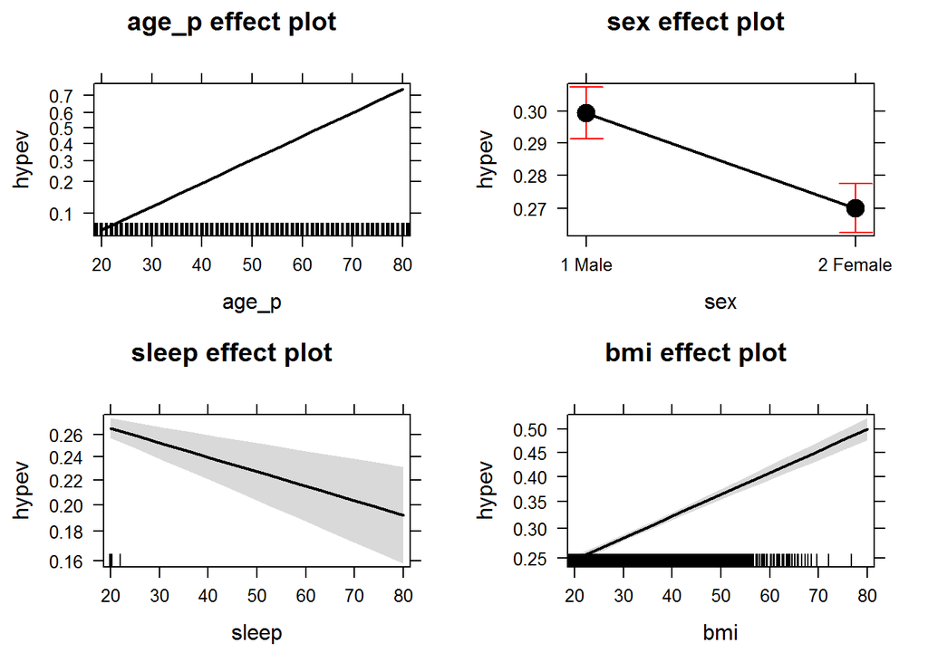

```r
library(effects)
plot(allEffects(hyp.out))
```

## Exercise: Logistic Regression

Now it’s time to give this a try for ourselves.

Using the NH11 data set from above:

1. Use `glm` to conduct a logistic regression to predict ever worked (`everwrk`) using age (`age_p`) and marital status (`r_maritl`).

```r
summary(NH11$everwrk)
```

```
##             1 Yes              2 No         7 Refused 8 Not ascertained
##             12153              1887                17                 0
##      9 Don't know              NA's
##                 8             18949
```

```r
wrkd.mod1 <- glm(everwrk ~ age_p + r_maritl,
            data = NH11,
            family = 'binomial')

summary(wrkd.mod1)
```

```
##
## Call:
## glm(formula = everwrk ~ age_p + r_maritl, family = "binomial",
##     data = NH11)
##
## Deviance Residuals:
##     Min       1Q   Median       3Q      Max
## -1.0429  -0.5675  -0.4452  -0.3384   2.7223
##
## Coefficients:
##                                              Estimate Std. Error z value
## (Intercept)                                 -0.454159   0.093080  -4.879
## age_p                                       -0.029346   0.001633 -17.966
## r_maritl2 Married - spouse not in household  0.081460   0.213836   0.381
## r_maritl4 Widowed                            0.686882   0.083623   8.214
## r_maritl5 Divorced                          -0.732113   0.111145  -6.587
## r_maritl6 Separated                         -0.116447   0.150190  -0.775
## r_maritl7 Never married                      0.355230   0.068865   5.158
## r_maritl8 Living with partner               -0.446226   0.137654  -3.242
## r_maritl9 Unknown marital status             0.541038   0.457838   1.182
##                                             Pr(>|z|)
## (Intercept)                                 1.07e-06 ***
## age_p                                        < 2e-16 ***
## r_maritl2 Married - spouse not in household  0.70324
## r_maritl4 Widowed                            < 2e-16 ***
## r_maritl5 Divorced                          4.49e-11 ***
## r_maritl6 Separated                          0.43814
## r_maritl7 Never married                     2.49e-07 ***
## r_maritl8 Living with partner                0.00119 **
## r_maritl9 Unknown marital status             0.23731
## ---
## Signif. codes:  0 '***' 0.001 '**' 0.01 '*' 0.05 '.' 0.1 ' ' 1
##
## (Dispersion parameter for binomial family taken to be 1)
##
##     Null deviance: 11182  on 14064  degrees of freedom
## Residual deviance: 10411  on 14056  degrees of freedom
##   (18949 observations deleted due to missingness)
## AIC: 10429
##
## Number of Fisher Scoring iterations: 5
```

There are quite a few NAs and some other non-yes/no. We are really only interested in the Yes/No responses. But if we were to exclude non-Yes/No’s, that still leaves us with 12153 Yes’s and 1887 No’s. Since `everwrk` is our dependent variable, we can’t really make up values for it, and since each observation represents a single person’s response, it’s best if we eliminate that person from our dataset for this model.

The other variable that we’ll look at is `age_p`, and `r_maritl`.

```r
summary(NH11$age_p)
```

```
##    Min. 1st Qu.  Median    Mean 3rd Qu.    Max.
##   18.00   33.00   47.00   48.11   62.00   85.00
```

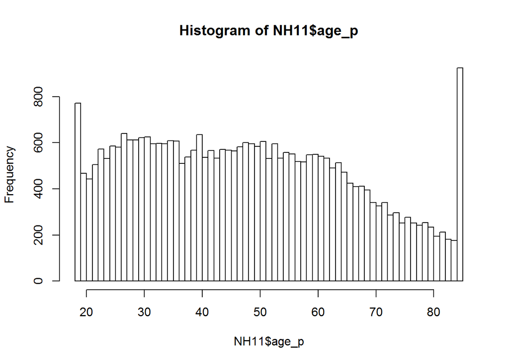

```r
hist(NH11$age_p, breaks = seq(18, 85, 1))
```

```r
summary(subset(NH11, !is.na(everwrk))$r_maritl)
```

```
##                        0 Under 14 years
##                                       0
##         1 Married - spouse in household
##                                    5464
##     2 Married - spouse not in household
##                                     213
## 3 Married - spouse in household unknown
##                                       0
##                               4 Widowed
##                                    2525
##                              5 Divorced
##                                    1908
##                             6 Separated
##                                     468
##                         7 Never married
##                                    2851
##                   8 Living with partner
##                                     601
##                9 Unknown marital status
##                                      35
```

```r
levels(NH11$r_maritl)
```

```
##  [1] "0 Under 14 years"
##  [2] "1 Married - spouse in household"
##  [3] "2 Married - spouse not in household"
##  [4] "3 Married - spouse in household unknown"
##  [5] "4 Widowed"
##  [6] "5 Divorced"
##  [7] "6 Separated"
##  [8] "7 Never married"
##  [9] "8 Living with partner"
## [10] "9 Unknown marital status"
```

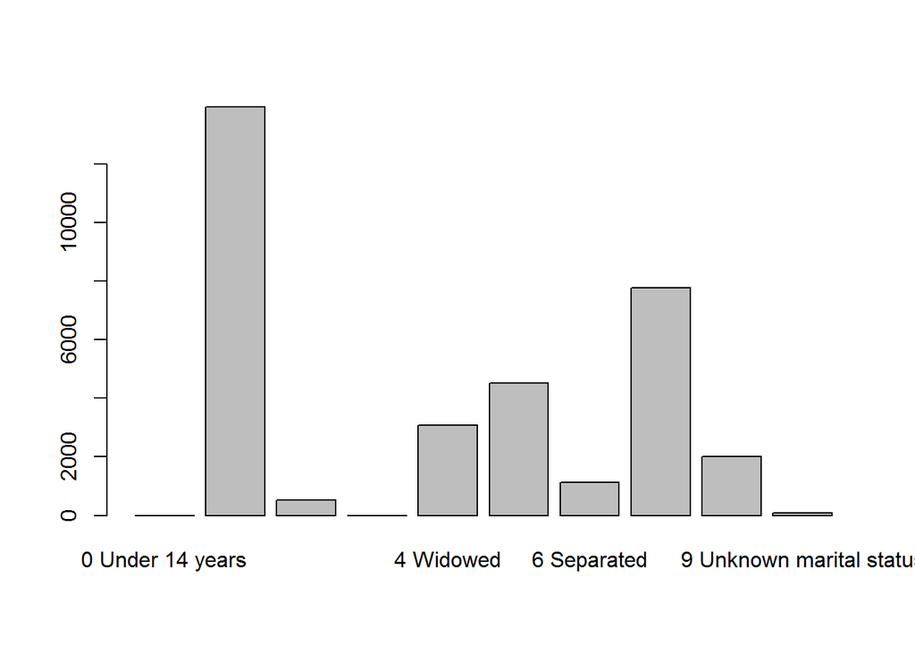

```r
plot(NH11$r_maritl,
     legend.text = levels(NH11$r_maritl))
```

```r
NH11 %>% group_by(r_maritl) %>% summarise(count = n())
```

```
## Source: local data frame [8 x 2]
##
##                              r_maritl count
##                                (fctr) (int)
## 1     1 Married - spouse in household 13943
## 2 2 Married - spouse not in household   531
## 3                           4 Widowed  3069
## 4                          5 Divorced  4511
## 5                         6 Separated  1121
## 6                     7 Never married  7763
## 7               8 Living with partner  2002
## 8            9 Unknown marital status    74
```

By looking at the variables we’re going to be using for our model, we’ll make a few adjustments:

1. Remove all NA observations of `everwrk`.
2. Filter the ages to exclude 18 and 85-year olds since those numbers are most likely erroneous points. It’s a survey, so probably has to do with the surveyor not getting an age but determining the subject was young (18) or old (85) (just an assumption).
3. We are only concerned with the binary response of `everwrk`: that is `1 Yes` or `2 No`.
4. Include only the categories of marital status with a response (there are 8).

```r
NH11.sub <- subset(NH11, age_p > 18 & age_p < 85 & !is.na(everwrk) &
                     (everwrk == "1 Yes" | everwrk == "2 No"))
```

Now that we have that set up - let’s refine our model and see if it’s improved.

```r
wrkd.mod2 <- glm(everwrk ~ age_p + r_maritl,
                 data = NH11.sub,
                 family = "binomial")

summary(wrkd.mod2)
```

```
##
## Call:
## glm(formula = everwrk ~ age_p + r_maritl, family = "binomial",
##     data = NH11.sub)
##
## Deviance Residuals:
##     Min       1Q   Median       3Q      Max
## -0.9546  -0.5563  -0.4401  -0.3480   2.6861
##
## Coefficients:
##                                              Estimate Std. Error z value
## (Intercept)                                 -0.522735   0.098264  -5.320
## age_p                                       -0.028139   0.001751 -16.066
## r_maritl2 Married - spouse not in household  0.030570   0.221095   0.138
## r_maritl4 Widowed                            0.507827   0.091873   5.528
## r_maritl5 Divorced                          -0.750037   0.112689  -6.656
## r_maritl6 Separated                         -0.127392   0.152486  -0.835
## r_maritl7 Never married                      0.238077   0.071790   3.316
## r_maritl8 Living with partner               -0.442884   0.140225  -3.158
## r_maritl9 Unknown marital status             0.156508   0.541594   0.289
##                                             Pr(>|z|)
## (Intercept)                                 1.04e-07 ***
## age_p                                        < 2e-16 ***
## r_maritl2 Married - spouse not in household 0.890032
## r_maritl4 Widowed                           3.25e-08 ***
## r_maritl5 Divorced                          2.82e-11 ***
## r_maritl6 Separated                         0.403475
## r_maritl7 Never married                     0.000912 ***
## r_maritl8 Living with partner               0.001586 **
## r_maritl9 Unknown marital status            0.772599
## ---
## Signif. codes:  0 '***' 0.001 '**' 0.01 '*' 0.05 '.' 0.1 ' ' 1
##
## (Dispersion parameter for binomial family taken to be 1)
##
##     Null deviance: 9879.0  on 12920  degrees of freedom
## Residual deviance: 9314.3  on 12912  degrees of freedom
## AIC: 9332.3
##
## Number of Fisher Scoring iterations: 5
```

2. Predict the probability of working for each level of marital status.

```r
## Setup variable for proper r_maritl levels (non-zero)
usable.maritl <- levels(NH11.sub$r_maritl)[
  which(table(NH11.sub$r_maritl) > 0)]

## Setup a predicting
predData <- with(NH11.sub,
                 expand.grid(r_maritl = usable.maritl,
                             age_p = mean(bmi, na.rm = TRUE)))

cbind(predData,
      predict(wrkd.mod2,
              type='response',
              se.fit=TRUE,
              interval = 'confidence',
              newdata = predData))
```

```
##                              r_maritl    age_p       fit      se.fit
## 1     1 Married - spouse in household 30.40137 0.2012981 0.008954256
## 2 2 Married - spouse not in household 30.40137 0.2062579 0.035871387
## 3                           4 Widowed 30.40137 0.2951765 0.021083879
## 4                          5 Divorced 30.40137 0.1063824 0.010676556
## 5                         6 Separated 30.40137 0.1815929 0.022098924
## 6                     7 Never married 30.40137 0.2422976 0.008877887
## 7               8 Living with partner 30.40137 0.1393038 0.015742286
## 8            9 Unknown marital status 30.40137 0.2276387 0.095189428
##   residual.scale
## 1              1
## 2              1
## 3              1
## 4              1
## 5              1
## 6              1
## 7              1
## 8              1
```

We can look at our independent variable’s effect on whether or not an individual has worked through use of the `effects` plot.

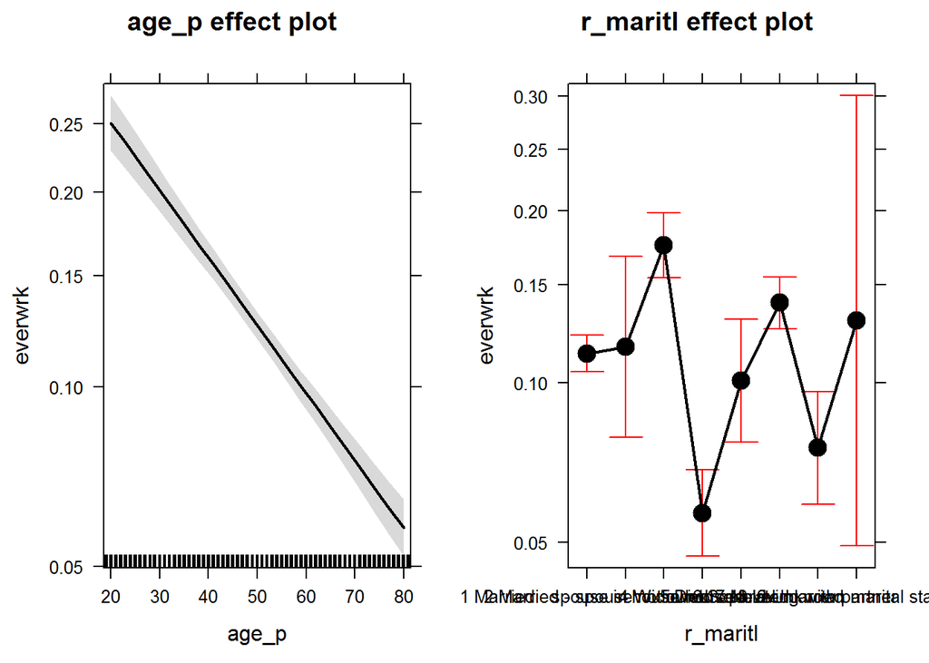

```r
plot(allEffects(wrkd.mod2))
```

While not the most useful of information, or best prediction, it’s at least a good exercise into determinig what the data tells us.

[^1]: [CDC Website](http://www.cdc.gov/nchs/nhis.html)